# LLNF_summary_final

Savants

12/13/2019

##### This HTML file contains the summary about the “Linda Loring Nature Foundation Project Analysis”. We have includes brief description about below points

- Target Audience,
- Source data Processing,
- Source data description,
- Rplots with interpretaion,
- Recommandations

## Target Audiences and Decisions

Linda Loring Nature Foundation(LLNF) holdes the mission as it states on the website, “the Linda Loring Nature Foundation is dedicated to preserving and protecting Nantucket’s biologically diverse ecosystems. The Foundation’s property, a living laboratory for research and education, advances broad community support and environmental understanding to respect the fragile habitats surrounding us”. (“Linda Loring Nature Foundation Mission,” n.d.) LLNF has been striving to observe the growth of the species and sustain the diversity of the biological ecosystems. Therefore, the organization needs not only raise different species but also closely monitor and analyze the factors that could influence the growth of the species. In addition, LLNF also strives to enhance public understanding of the natural environment by serving as a living lab for research and education. It enables people from different scientific fields to benefit from their resources.Linda Loring Nature Foundation is a non-profit organization located at Nantucket. This organization got his values from Linda Loring who was an advocate and conservationist. Her objective to establish this foundation was to create a nature centre at Nantucket.

The mission of Linda Loring & LLNF is education, staff work to connect people of all ages and background to nature and plays a vital role in the community of Nantucket. This foundation is mainly focused on three main areas of work: Ecological Research, Environmental Education, and Land Stewardship(“Linda Loring Nature Foundation”, n.d.). LLNF helps in preserving and protecting the biological environment of Nantucket which is very diverse. “Linda Loring Nature Foundation” being working towards such a good cause attracts many with their intensions of preserving the natural beauty. We have been working to contribute for the best towards this and finally we have some meaningful insights to present. We believe that officials working towards making the foundation flourish everyday will find our study very much helpful. With so much of visible changes in the environment, there is no one timesheet which is being followed by the nature and its components. And plants being of if the nature’s component, which holds number of phenophases in its life cycle needs to be studied on continuous basis to make sure that changes can be pointed out to work upon for continuous better results. Therefore, decision makers of the foundation, who care to introspect our findings to plan out their planning. Ultimate aim was to figure out the pattern which supports the theory as of what conditions are generally preferred by plants of different species at for different phenophase type.

Ultimately, we hope to base our theory to support human force who believe in protecting the fragile habitat we have around in the foundation and letting them know, what it takes to achieve so. People who praise the beauty of the foundation, needs to be aware the efforts the beauty demands. We are very specific with the plants and species we considered and therefore it needs to be make sure that our study may not support other studies which is being conducted on other species.Based on our study, concerned members of the foundation can take required measures to make sure that future maintenance of the plants will yield best results. Apart from us, there are many people who are working like us studying effects at different level, in the labs provided by the Foundation, which we hope will be amazed by our findings and use it to make further progress. Staff of the Foundation pursuing PhDs in the field of Data Analytics who have had already contributed towards. As our professor being our advisor and collaborated with Susan T. Bois to have us study on this, and spread our work and findings. Having this as everybody’s ultimate aim, people who cared to contribute in the past for the betterment of the cause may support the study as this will add more sense as what needs to be done next, having to keep the greenery intact there. On the top of it, for general study of plants as of how each of the driving factors and how changes in attributes of these factors effects the development of plant species can benefit people in general who works towards the flourishment of plants and nature.

### Source Data Processing

Data being recorded since long by concerned people was provided to us to study upon. Linda Lorin Nature Foundation made it easy for us to focus on the datasets at the first place which helped us to focus on studying the data rather to work on preparing or locating proper data which needs to be analyzed. On the top of it, we looked around for more sensible data to match both of the data sets so that all the factors we need to care about can be read at one place. The source data included many attributes but we were more focused on the effect of temperature on the soil and therefore we cared about the dates, timings in connection with the temperature at each point. We had to link this data to distinct phenophase types and therefore we want to thank “nature’s notebook” program to provide us with the data to reach up to the point where we have sensible data at the best. Which helped us to use both of our data sets together without having us going to the trouble of analyzing those differently.

### Source Data Description

About the Datasets Temperature Datasets: The temperature datasets that we initially obtained were separated by month and there were some missing values in the datasets. The format of the datasets is quite clean and not a lot of data cleaning work will be needed. I also focused on combining the datasets into one sheet divided by sites. Intensity Dataset: The intensity dataset is also cleaned but it has some missing values. The table comes with a clear explanation of each attribute as well as the observations Overview Summary Based on the analysis on our previous sessions, we’ve had the following interpretation:

##### Plot 1: Soil Temperature change Over Years:

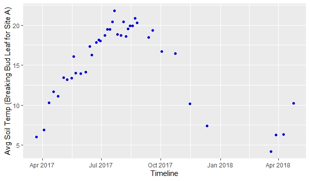

```r
knitr::include_graphics(rep('C:/Users/Dhwani/Documents/Soil2.jpeg', 1))
```

##### Plot 2: Presence of Species In a Year:

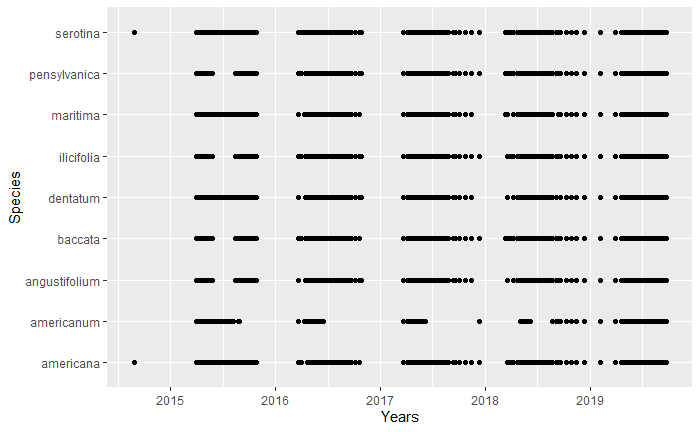

```r
knitr::include_graphics(rep('C:/Users/Dhwani/Documents/Species.png', 1))
```

species_presence This graph represents the Phenophase “Breaking bud leaf” for each species across the years on the Site A. We can plot for another sites with the same script. From the above graph we can conclude that breaking leave buds happens after April and stops around october. As it stays almost the same for all the species that we’ve plotted here, we would assume that it is possible for us to keep an appropriate to attain the healthy growth of all species. The growth pattern of breaking leave buds basically has two different categories:

The first category of species includes species such as Serotina that has breaking leave buds starting from around April and ending in around October. During that time period they have breaking leave buds continuously without stopping. The second category of species includes species such as Baccata that has breaking leave buds starting from around April and ending in around July. After stopping having their breaking leave buds phenophase for around two months or so, breaking leave buds re-occurs in around August and ends in October.

##### Plot 3: Relationship between Temperature and Phenophase:

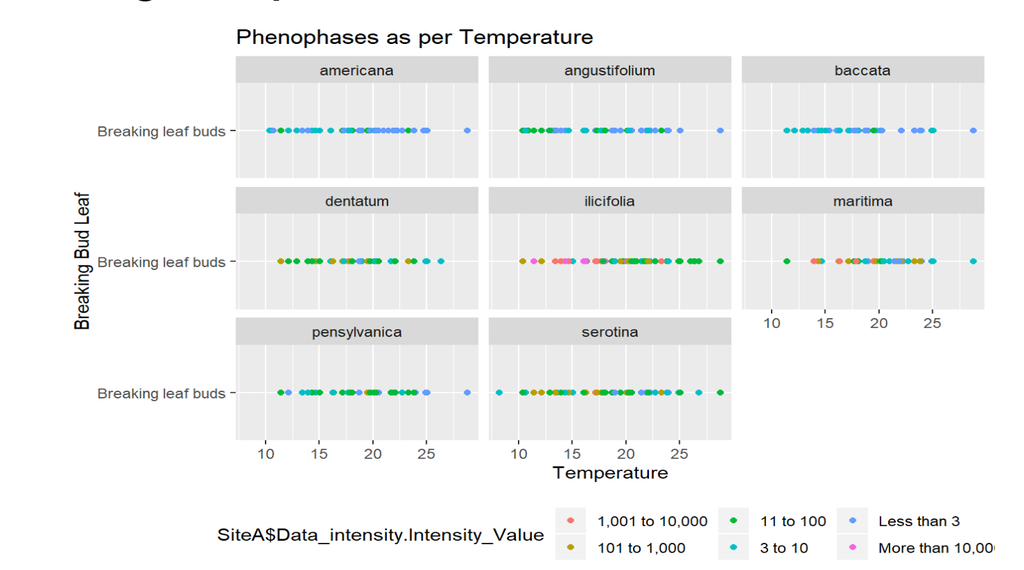

```r
knitr::include_graphics(rep('C:/Users/Dhwani/Documents/phenophase_vs_temp.png', 1))
```

##### Plot 4: Presence of Breaking Leave Buds Periods:

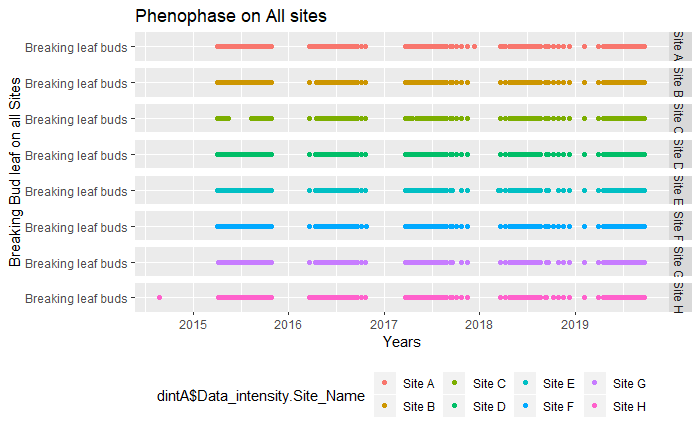

```r
knitr::include_graphics(rep('C:/Users/Dhwani/Documents/Species_allsites.png', 1))
```

##### Plot 5: Occurance of all Phenophases in a Year:

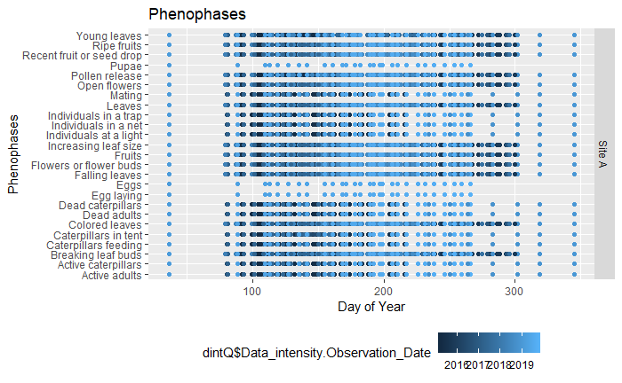

```r
knitr::opts_chunk$set(echo = FALSE)
knitr::include_graphics(rep('C:/Users/Dhwani/Documents/Phenophases.png', 1))
```

All_phenophases_year This plot shows the All Phenophase for each species on the Site A over the years from 2015 to 2019. In the example of “Egg” Phenophase, it happens between day 100- 280 of the year. Also from this graph we can more clearly tell that all phenophases happen almost the same time in the same pattern every year. The graph also indicates that in the year 2019 there are some outliers for every phenophase as they happened outside of the usual range of days compared to the past years. This might be something worth investigating to see what factors are likely to influence the occurence of these phenophases.

### Recommendations

The recommendations that we make are based on the following research questions:

Word Count: 2317

## REFERENCES

Linda Loring Nature Foundation Mission. (n.d.). Linda Loring Nature Foundation. Retrieved from https://llnf.org/mission Data Literacy. (n.d.). Renaissance. Retrieved from https://www.renaissance.com/edwords/data-literacy/

Linda Loring Nature Foundation. (2019, August 15). Retrieved from https://fishernantucket.com/linda-loring-nature-foundation.